# Scraping Unstructured Formats

## Before we begin

[figure not shown]

## Introduction

So far, we have seen:  
- How to replicate a crawler and get the content of a webpage  
- How to parse a mark-up language to extract content  
- How to automate the collection

## Introduction

**Still…**

Born on March, 26th 1924 or  
Site inspir� de perdu.com, pr�sent� � des fins p�dagogiques.

And this is not very easy to deal with…

## Introduction

These problems emerge  
- when scraping  
- but also when dealing with classic data sets (encoding, format, etc)  
- And you could work on raw text for many reasons (OCR, searching, etc)

## Introduction

**What we want to be able to do**

“Marie was Born on April, 15th 1992 in Paris ”  
“John was born on March, 12th (?) 1991 in N.Y.  
↓ ↓ ↓

| Who | Month | Day | Year | Place |
| --- | --- | --- | --- | --- |
| Marie | April | 15 | 1992 | Paris |
| John | March | 12 | 1991 | N.Y. |

## Introduction

The classic response to this is “Regular Expressions”  
also known as “rational expressions”, or “RegEx”

[figure not shown]

## Introduction

**Regex: What are They?**  
- A powerful “Search and Replace” tool  
- Identify a pattern in the text, and do something to it  
- They are central to working with unstructured data  
- Another tool for selection, on raw text this time  
- A common tool among programmers  
- An object of reverence and fascination

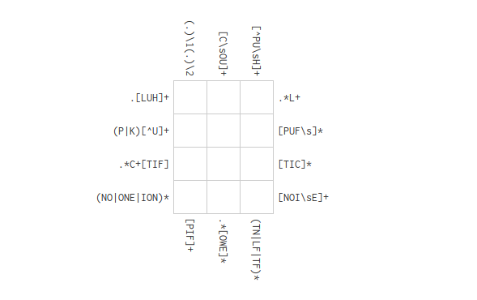

https://regexcrossword.com/

## Introduction

**Regex: What are They?**

**And in Practice**  
- YAPL!  
- Yet Another Programming Language

- But for our purpose, you will only need a few basic commands
- And there is plenty of help online.

## Outline

**Regex: Basic Syntax**  
- Basic query  
- Multiple choices  
- Jokers  
- Context  
- Quantifiers  
- Special characters

**And in Practice**  
- In R: Find  
- In R: Replace  
- Resources

## Regex: Basic Syntax

*Regex serve to do basic searches*  
The search pattern is *exact*

| Regex | Will match | Will not match |
| --- | --- | --- |
| “a” | “Laura” | “Roberto” |
| “Alexia” | “Alexia” | “Alexi” |
| “dataf” | “dataframe” | “data” |
| “19” | “1930” | “139” |
| “c_1” | “abc_1997” | “abc-1997” |

## Regex: Basic Syntax

*Multiple choice*  
There are a few operators that will help you [az8] = a or z or 8 [a-u] = All letters from a to u a|b = a or b

| Regex | Will match | Will not match |
| --- | --- | --- |
| “[Pp]aul” | “Pauline”, “epaule” | “Pau” |
| “P[a-z4]” | “Paula”, “Pbula”, “P4ula”, | “PAula |
| “P[a-zA-Z0-9]ul” | “Pbul”, “POul” | “P*ul” |
| “Dupont\|Dupond” | “Dupont”,“DuponDupond” | “Tintin” |

## Regex: Basic Syntax

*Jokers*  
They help you out when you are unsure.  
- \d = Any digit  
- \w = Any word, or digit, or _  
- . = Anything you want  
- [^a1&ast;] = Anything, except a, 1, or *

## Regex: Basic Syntax

*Context*  
They position your search pattern in the string  
^ = indicates the beginning of a string  
$ = indicates the end of a string  
\b = indicates the boundary of a word (no sign after)

| Regex | Will match | Will not match |
| --- | --- | --- |
| “^Paula” | “Paula likes John” | “John is liked by Paula” |
| “Paula$” | “John is liked by Paula” | “Paula likes John” |
| “Paul\b” | “Paul” | “Paula” |

## Regex: Basic Syntax

*Quantifiers*  
How many of these patterns do you want?  
- a{18} = a, 18 times in a row  
- a{7,} = a, 7 or more times in a row  
- a+ = a, once or more  
- a* = a, zero times or more  
- a? = 0 or 1 a (“is there an a?”)

| Regex | Will match | Will not match |
| --- | --- | --- |
| “Pa+ul” | “Paul”, “Paaaaul” | “Pul” |
| “Pa*ul” | “Pul”, “Paul” | “Pa#ula” |
| “\d{4}” | “1976”, “1234” | “123” |
| “a\d{3,}a” | “a1234a”, “a123a” | “a12a” |

## Regex: Basic Syntax

*Special characters*  
Sometimes, two languages mix in unpredictable ways

- * \ [] () ?

All of these are part of our common language (your string of character) and the regex language.

⇒ To capture them, you need to escape them (add \)

**In R, escaping requires not one but two \\**

## Regex: Basic Syntax

*Questions?*

## Regex: Basic Syntax

*Questions*

What will this pattern capture?

**.***

## Regex: Basic Syntax

*Questions*

And what about this one?

**\b[a-zA-Z0-9._%+-]+@[a-zA-Z0-9.-]+\.[a-zA-Z]{2,4}\b**

## In practice

**Search in R**

grep(REGEX, VECTOR)

text ← c(“alice”, “Carole”, “Bob”)

grep(“a”, text) will return 1 – 2, ie. the index (the position) of the matching elements.  
Note this this is an “index vector”. In can then be used to select and subset.  
grep(a, text, value = T) will return “alice” “Carole”  
This is useful to see that your regex works

## In practice

**Replace in R**

gsub(REGEX, REPLACEMENT, VECTOR)

text ← c(“ Alice ”, “ Carole ”, “B ob”)  
gsub(“ ”, “”, text) will return the first names, without space  
gsub(“\\s”, “”, text) will also delete all spaces  
gsub(“^\\s|\\s$”, “”, text) → What will this do?

## In practice

**Replace in R**

gsub(REGEX, REPLACEMENT, VECTOR)

text ← c(“on the year 1515”, “Party like its 1999”)  
gsub(“\\d”, “”, text) will return only not-numbers  
gsub(“\\D”, “”, text) will return only numbers

## In practice

**Replace in R**

gsub(REGEX, REPLACEMENT, VECTOR)

But this is a bad way to do extraction, and we can be more precise

text ← c(“ Party like its 1999”)  
gsub(“^(.*) (\\d{1,4})”, \\1 \\2”, text)

## In practice

gsub(REGEX, REPLACEMENT, VECTOR)

Of course, this gets more useful in certain circumstances

## In practice

**Resources**  
Regex can be hard, but most of what you’ll have to do it easy.  
In addition to this, there are countless resources online  
http://regex101.com → Test your regex (and add another \ in R) https://www.rexegg.com/

## Conclusion

6 h of lectures, 6h of labs, sweat, headaches, data & objects, tears and frustration… but in the end, it all boils down to this:

1. Get the source code
2. Select some elements
3. Store
4. Automate
5. Clean-up your data set

[figure not shown]